# Optimal Treatment Analysis

## Outcome Variable

**Outcome Variable:** ever_stunted

## Predictor Variables

**Intervention Variable:** cleanck

**Adjustment Set:**

- arm
- sex
- W_mage
- meducyrs
- feducyrs
- hhwealth_quart
- hfoodsec
- W_nrooms
- W_nhh
- W_nchldlt5
- W_parity
- impfloor
- delta_meducyrs
- delta_feducyrs
- delta_hhwealth_quart
- delta_hfoodsec
- delta_W_nrooms
- delta_W_nhh
- delta_W_nchldlt5
- delta_W_parity
- delta_impfloor

## Stratifying Variables

The analysis was stratified on these variable(s):

- agecat
- studyid
- country

## Data Summary

| agecat | studyid | country | cleanck | ever_stunted | n_cell | n |
| --- | --- | --- | --- | --- | --- | --- |
| 0-24 months (no birth st.) | ki0047075b-MAL-ED | PERU | 0 | 0 | 0 | 2 |
| 0-24 months (no birth st.) | ki0047075b-MAL-ED | PERU | 0 | 1 | 1 | 2 |
| 0-24 months (no birth st.) | ki0047075b-MAL-ED | PERU | 1 | 0 | 1 | 2 |
| 0-24 months (no birth st.) | ki0047075b-MAL-ED | PERU | 1 | 1 | 0 | 2 |
| 0-24 months (no birth st.) | ki0047075b-MAL-ED | SOUTH AFRICA | 0 | 0 | 1 | 1 |
| 0-24 months (no birth st.) | ki0047075b-MAL-ED | SOUTH AFRICA | 0 | 1 | 0 | 1 |
| 0-24 months (no birth st.) | ki0047075b-MAL-ED | SOUTH AFRICA | 1 | 0 | 0 | 1 |
| 0-24 months (no birth st.) | ki0047075b-MAL-ED | SOUTH AFRICA | 1 | 1 | 0 | 1 |
| 0-24 months (no birth st.) | ki1000108-CMC-V-BCS-2002 | INDIA | 0 | 0 | 7 | 296 |
| 0-24 months (no birth st.) | ki1000108-CMC-V-BCS-2002 | INDIA | 0 | 1 | 147 | 296 |
| 0-24 months (no birth st.) | ki1000108-CMC-V-BCS-2002 | INDIA | 1 | 0 | 21 | 296 |
| 0-24 months (no birth st.) | ki1000108-CMC-V-BCS-2002 | INDIA | 1 | 1 | 121 | 296 |
| 0-24 months (no birth st.) | ki1000108-IRC | INDIA | 0 | 0 | 49 | 352 |
| 0-24 months (no birth st.) | ki1000108-IRC | INDIA | 0 | 1 | 95 | 352 |
| 0-24 months (no birth st.) | ki1000108-IRC | INDIA | 1 | 0 | 94 | 352 |
| 0-24 months (no birth st.) | ki1000108-IRC | INDIA | 1 | 1 | 114 | 352 |
| 0-24 months (no birth st.) | ki1017093b-PROVIDE | BANGLADESH | 0 | 0 | 55 | 634 |
| 0-24 months (no birth st.) | ki1017093b-PROVIDE | BANGLADESH | 0 | 1 | 58 | 634 |
| 0-24 months (no birth st.) | ki1017093b-PROVIDE | BANGLADESH | 1 | 0 | 341 | 634 |
| 0-24 months (no birth st.) | ki1017093b-PROVIDE | BANGLADESH | 1 | 1 | 180 | 634 |
| 0-24 months (no birth st.) | ki1017093c-NIH-Crypto | BANGLADESH | 0 | 0 | 119 | 498 |
| 0-24 months (no birth st.) | ki1017093c-NIH-Crypto | BANGLADESH | 0 | 1 | 65 | 498 |
| 0-24 months (no birth st.) | ki1017093c-NIH-Crypto | BANGLADESH | 1 | 0 | 199 | 498 |
| 0-24 months (no birth st.) | ki1017093c-NIH-Crypto | BANGLADESH | 1 | 1 | 115 | 498 |
| 0-24 months (no birth st.) | ki1113344-GMS-Nepal | NEPAL | 0 | 0 | 328 | 954 |
| 0-24 months (no birth st.) | ki1113344-GMS-Nepal | NEPAL | 0 | 1 | 608 | 954 |
| 0-24 months (no birth st.) | ki1113344-GMS-Nepal | NEPAL | 1 | 0 | 14 | 954 |
| 0-24 months (no birth st.) | ki1113344-GMS-Nepal | NEPAL | 1 | 1 | 4 | 954 |
| 0-6 months (no birth st.) | ki0047075b-MAL-ED | PERU | 0 | 0 | 0 | 2 |
| 0-6 months (no birth st.) | ki0047075b-MAL-ED | PERU | 0 | 1 | 1 | 2 |
| 0-6 months (no birth st.) | ki0047075b-MAL-ED | PERU | 1 | 0 | 1 | 2 |
| 0-6 months (no birth st.) | ki0047075b-MAL-ED | PERU | 1 | 1 | 0 | 2 |
| 0-6 months (no birth st.) | ki0047075b-MAL-ED | SOUTH AFRICA | 0 | 0 | 1 | 1 |
| 0-6 months (no birth st.) | ki0047075b-MAL-ED | SOUTH AFRICA | 0 | 1 | 0 | 1 |
| 0-6 months (no birth st.) | ki0047075b-MAL-ED | SOUTH AFRICA | 1 | 0 | 0 | 1 |
| 0-6 months (no birth st.) | ki0047075b-MAL-ED | SOUTH AFRICA | 1 | 1 | 0 | 1 |
| 0-6 months (no birth st.) | ki1000108-CMC-V-BCS-2002 | INDIA | 0 | 0 | 84 | 292 |
| 0-6 months (no birth st.) | ki1000108-CMC-V-BCS-2002 | INDIA | 0 | 1 | 67 | 292 |
| 0-6 months (no birth st.) | ki1000108-CMC-V-BCS-2002 | INDIA | 1 | 0 | 96 | 292 |
| 0-6 months (no birth st.) | ki1000108-CMC-V-BCS-2002 | INDIA | 1 | 1 | 45 | 292 |
| 0-6 months (no birth st.) | ki1000108-IRC | INDIA | 0 | 0 | 87 | 352 |
| 0-6 months (no birth st.) | ki1000108-IRC | INDIA | 0 | 1 | 57 | 352 |
| 0-6 months (no birth st.) | ki1000108-IRC | INDIA | 1 | 0 | 143 | 352 |
| 0-6 months (no birth st.) | ki1000108-IRC | INDIA | 1 | 1 | 65 | 352 |
| 0-6 months (no birth st.) | ki1017093b-PROVIDE | BANGLADESH | 0 | 0 | 86 | 634 |
| 0-6 months (no birth st.) | ki1017093b-PROVIDE | BANGLADESH | 0 | 1 | 27 | 634 |
| 0-6 months (no birth st.) | ki1017093b-PROVIDE | BANGLADESH | 1 | 0 | 447 | 634 |
| 0-6 months (no birth st.) | ki1017093b-PROVIDE | BANGLADESH | 1 | 1 | 74 | 634 |
| 0-6 months (no birth st.) | ki1017093c-NIH-Crypto | BANGLADESH | 0 | 0 | 150 | 498 |
| 0-6 months (no birth st.) | ki1017093c-NIH-Crypto | BANGLADESH | 0 | 1 | 34 | 498 |
| 0-6 months (no birth st.) | ki1017093c-NIH-Crypto | BANGLADESH | 1 | 0 | 262 | 498 |
| 0-6 months (no birth st.) | ki1017093c-NIH-Crypto | BANGLADESH | 1 | 1 | 52 | 498 |
| 0-6 months (no birth st.) | ki1113344-GMS-Nepal | NEPAL | 0 | 0 | 754 | 954 |
| 0-6 months (no birth st.) | ki1113344-GMS-Nepal | NEPAL | 0 | 1 | 182 | 954 |
| 0-6 months (no birth st.) | ki1113344-GMS-Nepal | NEPAL | 1 | 0 | 18 | 954 |
| 0-6 months (no birth st.) | ki1113344-GMS-Nepal | NEPAL | 1 | 1 | 0 | 954 |
| 6-24 months | ki1000108-CMC-V-BCS-2002 | INDIA | 0 | 0 | 7 | 185 |
| 6-24 months | ki1000108-CMC-V-BCS-2002 | INDIA | 0 | 1 | 81 | 185 |
| 6-24 months | ki1000108-CMC-V-BCS-2002 | INDIA | 1 | 0 | 21 | 185 |
| 6-24 months | ki1000108-CMC-V-BCS-2002 | INDIA | 1 | 1 | 76 | 185 |
| 6-24 months | ki1000108-IRC | INDIA | 0 | 0 | 49 | 230 |
| 6-24 months | ki1000108-IRC | INDIA | 0 | 1 | 38 | 230 |
| 6-24 months | ki1000108-IRC | INDIA | 1 | 0 | 94 | 230 |
| 6-24 months | ki1000108-IRC | INDIA | 1 | 1 | 49 | 230 |
| 6-24 months | ki1017093b-PROVIDE | BANGLADESH | 0 | 0 | 35 | 457 |
| 6-24 months | ki1017093b-PROVIDE | BANGLADESH | 0 | 1 | 31 | 457 |
| 6-24 months | ki1017093b-PROVIDE | BANGLADESH | 1 | 0 | 285 | 457 |
| 6-24 months | ki1017093b-PROVIDE | BANGLADESH | 1 | 1 | 106 | 457 |
| 6-24 months | ki1017093c-NIH-Crypto | BANGLADESH | 0 | 0 | 118 | 397 |
| 6-24 months | ki1017093c-NIH-Crypto | BANGLADESH | 0 | 1 | 31 | 397 |
| 6-24 months | ki1017093c-NIH-Crypto | BANGLADESH | 1 | 0 | 185 | 397 |
| 6-24 months | ki1017093c-NIH-Crypto | BANGLADESH | 1 | 1 | 63 | 397 |
| 6-24 months | ki1113344-GMS-Nepal | NEPAL | 0 | 0 | 318 | 760 |
| 6-24 months | ki1113344-GMS-Nepal | NEPAL | 0 | 1 | 426 | 760 |
| 6-24 months | ki1113344-GMS-Nepal | NEPAL | 1 | 0 | 12 | 760 |
| 6-24 months | ki1113344-GMS-Nepal | NEPAL | 1 | 1 | 4 | 760 |

The following strata were considered:

- agecat: 0-24 months (no birth st.), studyid: ki0047075b-MAL-ED, country: PERU
- agecat: 0-24 months (no birth st.), studyid: ki0047075b-MAL-ED, country: SOUTH AFRICA
- agecat: 0-24 months (no birth st.), studyid: ki1000108-CMC-V-BCS-2002, country: INDIA
- agecat: 0-24 months (no birth st.), studyid: ki1000108-IRC, country: INDIA
- agecat: 0-24 months (no birth st.), studyid: ki1017093b-PROVIDE, country: BANGLADESH
- agecat: 0-24 months (no birth st.), studyid: ki1017093c-NIH-Crypto, country: BANGLADESH
- agecat: 0-24 months (no birth st.), studyid: ki1113344-GMS-Nepal, country: NEPAL
- agecat: 0-6 months (no birth st.), studyid: ki0047075b-MAL-ED, country: PERU
- agecat: 0-6 months (no birth st.), studyid: ki0047075b-MAL-ED, country: SOUTH AFRICA
- agecat: 0-6 months (no birth st.), studyid: ki1000108-CMC-V-BCS-2002, country: INDIA
- agecat: 0-6 months (no birth st.), studyid: ki1000108-IRC, country: INDIA
- agecat: 0-6 months (no birth st.), studyid: ki1017093b-PROVIDE, country: BANGLADESH
- agecat: 0-6 months (no birth st.), studyid: ki1017093c-NIH-Crypto, country: BANGLADESH
- agecat: 0-6 months (no birth st.), studyid: ki1113344-GMS-Nepal, country: NEPAL
- agecat: 6-24 months, studyid: ki1000108-CMC-V-BCS-2002, country: INDIA
- agecat: 6-24 months, studyid: ki1000108-IRC, country: INDIA
- agecat: 6-24 months, studyid: ki1017093b-PROVIDE, country: BANGLADESH
- agecat: 6-24 months, studyid: ki1017093c-NIH-Crypto, country: BANGLADESH
- agecat: 6-24 months, studyid: ki1113344-GMS-Nepal, country: NEPAL

### Dropped Strata

Some strata were dropped due to rare outcomes:

- agecat: 0-24 months (no birth st.), studyid: ki0047075b-MAL-ED, country: PERU
- agecat: 0-24 months (no birth st.), studyid: ki0047075b-MAL-ED, country: SOUTH AFRICA
- agecat: 0-24 months (no birth st.), studyid: ki1113344-GMS-Nepal, country: NEPAL
- agecat: 0-6 months (no birth st.), studyid: ki0047075b-MAL-ED, country: PERU
- agecat: 0-6 months (no birth st.), studyid: ki0047075b-MAL-ED, country: SOUTH AFRICA
- agecat: 0-6 months (no birth st.), studyid: ki1113344-GMS-Nepal, country: NEPAL
- agecat: 6-24 months, studyid: ki1113344-GMS-Nepal, country: NEPAL

## Methods Detail

We’re interested in the causal parameters $E[Y_a]$ for all values of $a \in \mathcal{A}$. These parameters represent the mean outcome if, possibly contrary to fact, we intervened to set all units to have $A=a$. Under the randomization and positivity assumptions, these are identified by the statistical parameters $\psi_a=E_W[E_{Y|A,W}(Y|A=a,W)]$. In addition, we’re interested in the mean of $Y$, $E[Y]$ under no intervention (the observed mean). We will estimate these parameters by using SuperLearner to fit the relevant likelihood factors – $E_{Y|A,W}(Y|A=a,W)$ and $p(A=a|W)$, and then updating our likelihood fit using a joint TMLE.

For unadjusted analyses ($W=\{\}$), initial likelihoods were estimated using Lrnr_glm to estimate the simple $E(Y|A)$ and Lrnr_mean to estimate $p(A)$. For adjusted analyses, a small library containing Lrnr_glmnet, Lrnr_xgboost, and Lrnr_mean was used.

# Results Detail

## Results Plots

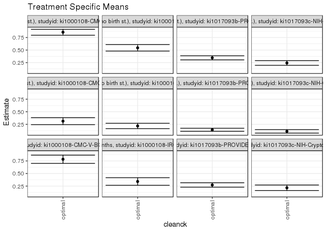

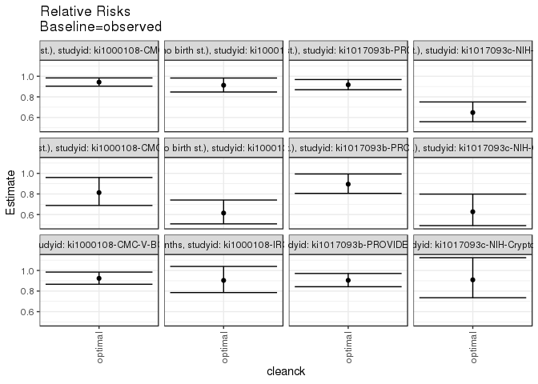

## Results Table

### Parameter: TSM

| agecat | studyid | country | intervention_level | baseline_level | estimate | ci_lower | ci_upper |
| --- | --- | --- | --- | --- | --- | --- | --- |
| 0-24 months (no birth st.) | ki1000108-CMC-V-BCS-2002 | INDIA | optimal | NA | 0.8538736 | 0.7953871 | 0.9123601 |
| 0-24 months (no birth st.) | ki1000108-IRC | INDIA | optimal | NA | 0.5441080 | 0.4800453 | 0.6081706 |
| 0-24 months (no birth st.) | ki1017093b-PROVIDE | BANGLADESH | optimal | NA | 0.3452113 | 0.3047403 | 0.3856824 |
| 0-24 months (no birth st.) | ki1017093c-NIH-Crypto | BANGLADESH | optimal | NA | 0.2431021 | 0.1967809 | 0.2894234 |
| 0-6 months (no birth st.) | ki1000108-CMC-V-BCS-2002 | INDIA | optimal | NA | 0.3134572 | 0.2441162 | 0.3827982 |
| 0-6 months (no birth st.) | ki1000108-IRC | INDIA | optimal | NA | 0.2177426 | 0.1638819 | 0.2716032 |
| 0-6 months (no birth st.) | ki1017093b-PROVIDE | BANGLADESH | optimal | NA | 0.1422754 | 0.1123713 | 0.1721795 |
| 0-6 months (no birth st.) | ki1017093c-NIH-Crypto | BANGLADESH | optimal | NA | 0.1108034 | 0.0759966 | 0.1456101 |
| 6-24 months | ki1000108-CMC-V-BCS-2002 | INDIA | optimal | NA | 0.7835967 | 0.7014134 | 0.8657801 |
| 6-24 months | ki1000108-IRC | INDIA | optimal | NA | 0.3412387 | 0.2656334 | 0.4168439 |
| 6-24 months | ki1017093b-PROVIDE | BANGLADESH | optimal | NA | 0.2717278 | 0.2279734 | 0.3154822 |
| 6-24 months | ki1017093c-NIH-Crypto | BANGLADESH | optimal | NA | 0.2162297 | 0.1605125 | 0.2719470 |

### Parameter: E(Y)

| agecat | studyid | country | intervention_level | baseline_level | estimate | ci_lower | ci_upper |
| --- | --- | --- | --- | --- | --- | --- | --- |
| 0-24 months (no birth st.) | ki1000108-CMC-V-BCS-2002 | INDIA | observed | NA | 0.9056254 | 0.8722296 | 0.9390212 |
| 0-24 months (no birth st.) | ki1000108-IRC | INDIA | observed | NA | 0.5962935 | 0.5449136 | 0.6476734 |
| 0-24 months (no birth st.) | ki1017093b-PROVIDE | BANGLADESH | observed | NA | 0.3763399 | 0.3386180 | 0.4140617 |
| 0-24 months (no birth st.) | ki1017093c-NIH-Crypto | BANGLADESH | observed | NA | 0.3755064 | 0.3332697 | 0.4177431 |
| 0-6 months (no birth st.) | ki1000108-CMC-V-BCS-2002 | INDIA | observed | NA | 0.3856069 | 0.3297387 | 0.4414750 |
| 0-6 months (no birth st.) | ki1000108-IRC | INDIA | observed | NA | 0.3542845 | 0.3044998 | 0.4040692 |
| 0-6 months (no birth st.) | ki1017093b-PROVIDE | BANGLADESH | observed | NA | 0.1589851 | 0.1304762 | 0.1874941 |
| 0-6 months (no birth st.) | ki1017093c-NIH-Crypto | BANGLADESH | observed | NA | 0.1766446 | 0.1434140 | 0.2098753 |
| 6-24 months | ki1000108-CMC-V-BCS-2002 | INDIA | observed | NA | 0.8485420 | 0.7967579 | 0.9003261 |
| 6-24 months | ki1000108-IRC | INDIA | observed | NA | 0.3776877 | 0.3148775 | 0.4404979 |
| 6-24 months | ki1017093b-PROVIDE | BANGLADESH | observed | NA | 0.3004789 | 0.2584271 | 0.3425307 |
| 6-24 months | ki1017093c-NIH-Crypto | BANGLADESH | observed | NA | 0.2378615 | 0.1959922 | 0.2797308 |

### Parameter: RR

| agecat | studyid | country | intervention_level | baseline_level | estimate | ci_lower | ci_upper |
| --- | --- | --- | --- | --- | --- | --- | --- |
| 0-24 months (no birth st.) | ki1000108-CMC-V-BCS-2002 | INDIA | optimal | observed | 0.9428552 | 0.9036456 | 0.9837661 |
| 0-24 months (no birth st.) | ki1000108-IRC | INDIA | optimal | observed | 0.9124835 | 0.8471647 | 0.9828386 |
| 0-24 months (no birth st.) | ki1017093b-PROVIDE | BANGLADESH | optimal | observed | 0.9172861 | 0.8693273 | 0.9678907 |
| 0-24 months (no birth st.) | ki1017093c-NIH-Crypto | BANGLADESH | optimal | observed | 0.6473980 | 0.5585375 | 0.7503959 |
| 0-6 months (no birth st.) | ki1000108-CMC-V-BCS-2002 | INDIA | optimal | observed | 0.8128931 | 0.6884470 | 0.9598346 |
| 0-6 months (no birth st.) | ki1000108-IRC | INDIA | optimal | observed | 0.6145981 | 0.5097234 | 0.7410504 |
| 0-6 months (no birth st.) | ki1017093b-PROVIDE | BANGLADESH | optimal | observed | 0.8948976 | 0.8055827 | 0.9941148 |
| 0-6 months (no birth st.) | ki1017093c-NIH-Crypto | BANGLADESH | optimal | observed | 0.6272671 | 0.4926718 | 0.7986329 |
| 6-24 months | ki1000108-CMC-V-BCS-2002 | INDIA | optimal | observed | 0.9234625 | 0.8663774 | 0.9843089 |
| 6-24 months | ki1000108-IRC | INDIA | optimal | observed | 0.9034942 | 0.7855767 | 1.0391115 |
| 6-24 months | ki1017093b-PROVIDE | BANGLADESH | optimal | observed | 0.9043156 | 0.8421846 | 0.9710303 |
| 6-24 months | ki1017093c-NIH-Crypto | BANGLADESH | optimal | observed | 0.9090572 | 0.7353370 | 1.1238181 |